# Latihan Praktikum 4

## 3.1 Karakteristik AR(2)

Plot deret waktu, fungsi autokorelasi (ACF), serta korelasi parsial (PACF) dimunculkan untuk inspeksi stabilitas model.

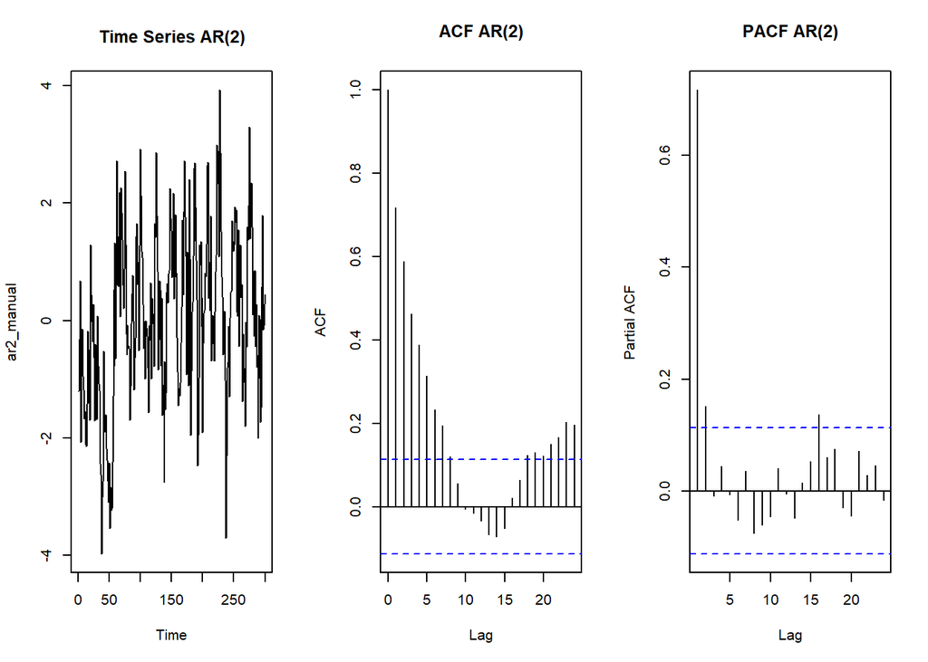

```r
par(mfrow = c(1, 3))
ts.plot(ar2_manual, main="Time Series AR(2)")
acf(ar2_manual, main="ACF AR(2)")
pacf(ar2_manual, main="PACF AR(2)")
```

Plot Time Series: Fluktuasi observasi stabil di sekitar rataan nol, menunjukkan bahwa proses AR(2) yang dibangkitkan stasioner.

Plot ACF: Tails off (meluruh secara perlahan seiring bertambahnya lag).

Plot PACF: Cuts off secara tegas setelah lag ke-2, sifat khas dari proses Autoregressive orde 2.

Pengujian matriks ordo ditelusuri menggunakan struktur baris dari segitiga nol tabel EACF.

```r
TSA::eacf(ar2_manual)
```

```
## AR/MA
##   0 1 2 3 4 5 6 7 8 9 10 11 12 13
## 0 x x x x x x x x o o o  o  o  o
## 1 x o o o o o o o o o o  o  o  o
## 2 o o o o o o o o o o o  o  o  o
## 3 x x o o o o o o o o o  o  o  o
## 4 x x o o o o o o o o o  o  o  o
## 5 o x o x o o x o o o o  o  o  o
## 6 x x x x o o o o o o o  o  o  o
## 7 x x x o x x o o o o o  o  o  o
```

## 3.2 Scatterplot dan Autokorelasi

Bentuk kemiringan positif pada sebaran observasi masa kini dan historis dikaji dalam ruang dua dimensi antar lag.

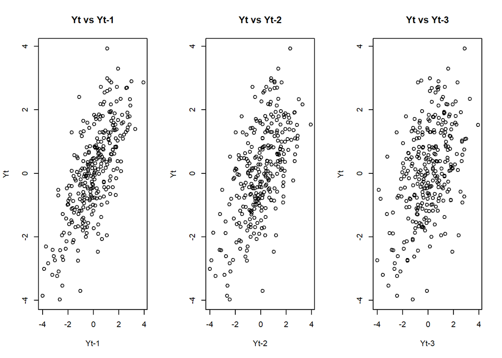

```r
yt_ar2   <- ar2_manual[-c(1:3)]
yt_1_ar2 <- ar2_manual[-c(1:2, 300)]
yt_2_ar2 <- ar2_manual[-c(1, 299:300)]
yt_3_ar2 <- ar2_manual[-c(298:300)]

par(mfrow = c(1, 3))
plot(yt_1_ar2, yt_ar2, main="Yt vs Yt-1", xlab="Yt-1", ylab="Yt")
plot(yt_2_ar2, yt_ar2, main="Yt vs Yt-2", xlab="Yt-2", ylab="Yt")
plot(yt_3_ar2, yt_ar2, main="Yt vs Yt-3", xlab="Yt-3", ylab="Yt")
```

Ketiga plot ($Y_t$ terhadap $Y_{t-1}$, $Y_{t-2}$, dan $Y_{t-3}$) memperlihatkan pola kemiringan positif yang meluruh secara bertahap seiring bertambahnya rentang kelambanan waktu.

```r
cat("Korelasi Simulasi Yt vs Yt-1 :", cor(yt_ar2, yt_1_ar2), "\n")
```

```
## Korelasi Simulasi Yt vs Yt-1 : 0.7191133
```

```r
cat("Korelasi Simulasi Yt vs Yt-2 :", cor(yt_ar2, yt_2_ar2), "\n")
```

```
## Korelasi Simulasi Yt vs Yt-2 : 0.5911747
```

```r
cat("Korelasi Simulasi Yt vs Yt-3 :", cor(yt_ar2, yt_3_ar2), "\n")
```

```
## Korelasi Simulasi Yt vs Yt-3 : 0.4630342
```

- $Y_t \text{ vs } Y_{t-1}$: Korelasi positif kuat; scatterplot membentuk pola diagonal linier yang jelas.
- $Y_t \text{ vs } Y_{t-2}$: Korelasi positif sedang; sebaran data sedikit melebar namun tetap menunjukkan tren naik.
- $Y_t \text{ vs } Y_{t-3}$: Korelasi positif moderat; ketergantungan antar-lag meluruh secara perlahan.

Ketiga plot ($Y_t$ terhadap $Y_{t-1}$, $Y_{t-2}$, dan $Y_{t-3}$) memperlihatkan pola kemiringan positif yang meluruh secara bertahap seiring bertambahnya rentang kelambanan waktu.